# Лабораторная работа №13

Задание для самостоятельного выполнения

Шубнякова Дарья НКНбд-01-22

1132226452@pfur.ru

Российский университет дружбы народов

# Вводная часть

## Цели и задачи

Реализовать модель. Заявка (команды программы, операнды) поступает в оперативную память (ОП), затем передается на прибор (центральный процессор, ЦП) для обработки. После этого заявка может равновероятно обратиться к оперативной памяти или к одному из двух внешних запоминающих устройств (B1 и B2). Прежде чем записать информацию на внешний накопитель, необходимо вторично обратиться к центральному процессору, определяющему состояние накопителя и выдающему необходимую управляющую информацию. Накопители (B1 и B2) могут работать в 3-х режимах: 1) B1 — занят, B2 — свободен; 2) B2 — свободен, B1 — занят; 3) B1 — занят, B2 — занят. Промоделировать сеть Петри в CPNTools. Определить, является ли сеть безопасной, ограниченной, сохраняющей, имеются ли тупики. Вычислить пространство состояний. Сформировать отчёт о пространстве состояний и проанализировать его. Построить граф пространства состояний.

# Основная часть

## Выполнение лабораторной работы

Создаем представленный в работе граф.

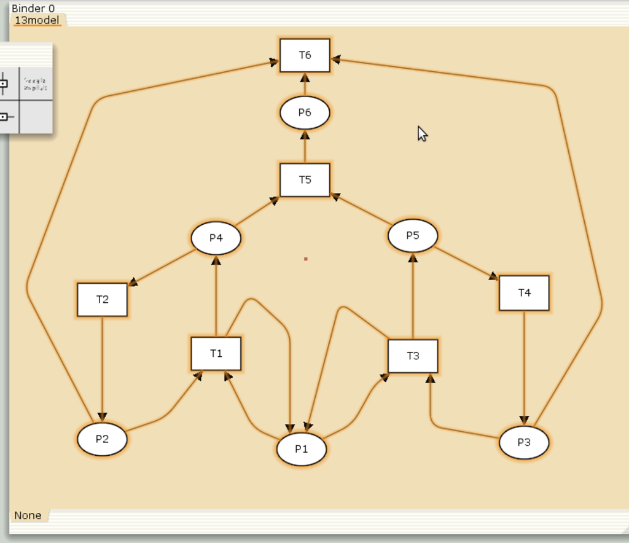

## Видим, что модель работает и симуляция запускается.

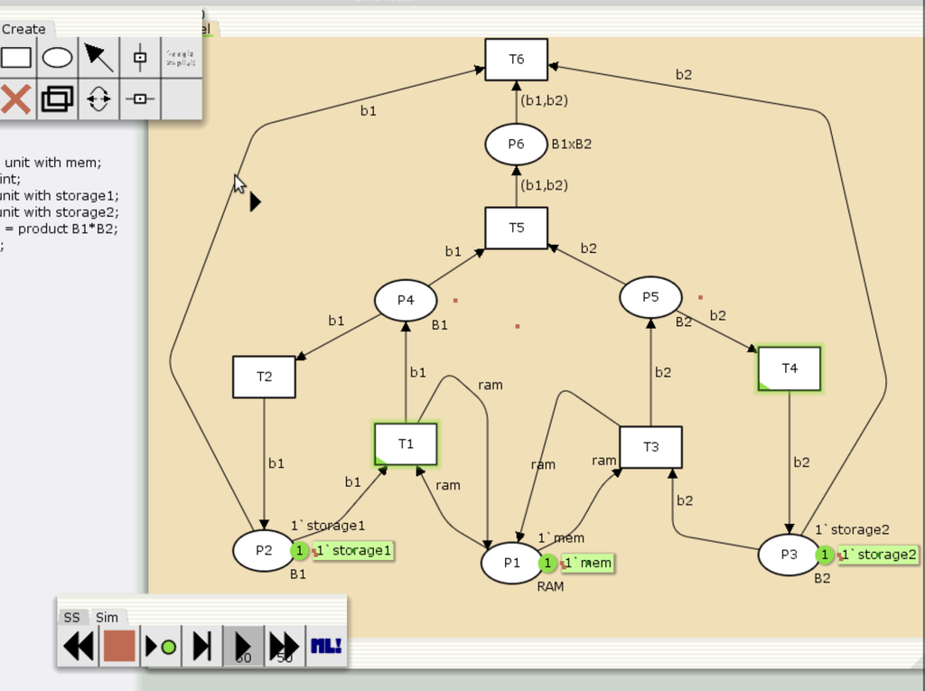

## Декларируем все необходимое.

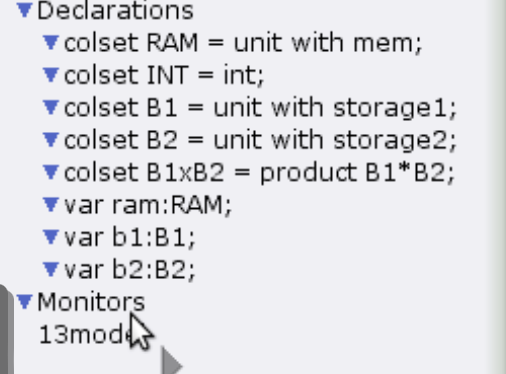

## Получаем отчет по состоянию системы, который представлен в выводах этого отчета и визуализурием состояние среды на графике.

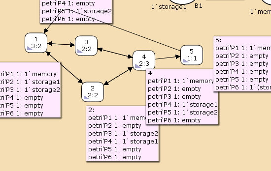

# Результаты

Мы выполнили самостоятельную работу. Boundedness Properties -> Best Integer Bounds (покажет, ограничена ли сеть и какое макс. количество фишек в каждой позиции). Если все верхние границы равны 1 — сеть безопасна. Поскольку в нашем отчете о состоянии системы видно, что везде стоят единички – значит наша система безопасна.

Тупики так же отсутствуют.

Dead Markings None

## Boundedness Properties

Best Integer Bounds Upper Lower petri’P1 1 1 1 petri’P2 1 1 0 petri’P3 1 1 0 petri’P4 1 1 0 petri’P5 1 1 0 petri’P6 1 1 0